# EDA Milestone Report

Stephen Bique

January 24, 2021

## Executive summary

The goal here is to build a simple model for the relationship between words. This is the first step in building a predictive text mining application. Later, we will explore simple models and discover more complicated modeling techniques.

Tasks to accomplish

- Build basic **n-gram** model - using the exploratory analysis you performed, build a basic **n-gram** model for predicting the next word based on the previous 1, 2, or 3 words.
- Build a model to handle unseen **n-grams** - in some cases people will want to type a combination of words that does not appear in the corpora. Build a model to handle cases where a particular **n-gram** isn’t observed.

In this context, an **n-gram model** is a type of probabilistic language model for predicting the next word given a so-called **n-gram**, which is just a phrase consisting of n words (Wikipedia contributors 2021b). Since phrases are not randomly ordered, it is natural to ask: what is the next word given a phrase? Answering this question appears at first glance to be plausible if we can answer the mathematical analog: what is the conditional probability that we find such word appearing after such phrase. Considering just the fact that languages constantly change, it turns out computing the conditional probability exactly is a hard problem to solve. It might be surprising, but we can *approximate* the conditional probability that takes into account all of the words in the phrase, by just the conditional probability of the last (n-1) words. So the **bigram** (2-gram) or **trigram**(3-gram) “looks” one word or two of the preceding words. The assumption that the probability of a word depends only on the previous (n - 1) words is called a **Markov** assumption (see Jurafsky and Martin 2020, 3–4)

We estimate the probabilities using the so-called **maximum likelihood estimation** (**MLE**) by getting counts from a *corpus* and normalizing (see Jurafsky and Martin 2020, 4). Let **C(p)** denote the normalized count of the phrase p. Let P denote the *approximate* probability. We calculate the **MLE**s as follows:

> **2-gram**: $P(xy \mid x) = \displaystyle \frac{C(xy)}{C(x)}$

> **3-gram**: $P(xyz \mid xy) = \displaystyle \frac{C(xyz)}{C(xy)}$

> **4-gram**: $P(wxyz \mid wxy) = \displaystyle \frac{C(wxyz)}{C(wxy)}$

Google’s simpler **Stupid Backoff** (SB) method with a constant backoff parameter of 0.4 has been used in cases when there is no history for the given prefix (see Brants et al. 2007). There are other techniques such as adding one to all of the counts, or the so-called **Simple Good–Turing** technique (see Sampson 2017; and Gale and Sampson 1995)

In our algorithm described next, we use the idea that if we fail to find desired n-gram then we *backtrack* by ignoring information, starting with the ‘oldest’ words, which is our variation of *Katz’s back-off model* (see Wikipedia contributors 2021a). The first three steps implement backtracking. The subsequent steps also implement backtracking when we ignore the third word. This approach may be useful when, for example, the third word is misspelled, an unneeded interjection or even not a word. Consider a phrase $wxy$, where $w$, $x$ and $y$ are words and, for convenience, we omit spaces. Perform the following steps:

1. If $wxyz_1$ is in **4-grams**, predict $z_1$ using highest observed ranking such 4-gram; otherwise, proceed to next step.
2. If $xyz_2$ is in **3-grams**, predict $z_2$ using highest observed ranking such 3-gram; otherwise, proceed to next step.
3. If $yz_3$ is in **2-grams**, predict $z_3$ using highest observed ranking such 2-gram; otherwise, proceed to next step.
4. If $wxz_4$ is in **3-grams**, predict $z_4$ using highest observed ranking such 3-gram, provided $z_4$ is not $y$; otherwise, proceed to next step.
5. If $xz_5$ is in **2-grams**, predict $z_5$ using highest observed ranking such 2-gram, provided $z_5$ is not $y$; otherwise, proceed to next step.
6. If $wz_6$ is in **2-grams**, predict $z_6$ using highest observed ranking such 2-gram, provided $z_6$ is not $y$; otherwise, predict end of phrase.

## Load libraries

```r
library("tidyverse")
library("lubridate")
library("lemon")
library("devtools")
library("formatR")
library("knitr")
```

## Data processing

Set *working directory* if needed.

Download data and unzip if needed.

```r
if (!file.exists("final")) {
    download.file("https://d396qusza40orc.cloudfront.net/dsscapstone/dataset/Coursera-SwiftKey.zip",
        destfile = "Coursera-SwiftKey.zip")
    if (file.exists("Coursera-SwiftKey.zip")) {
        unzip("Coursera-SwiftKey.zip")
        file.remove("Coursera-SwiftKey.zip")
    }
}
```

Read in text files and summarize data

```r
countWords <- function(Text) {
    return(as.list(sapply(Text, str_count, "\\w+")))
}

countCharacters <- function(Text) {
    return(as.list(sapply(Text, nchar)))
}

text2df <- function(Text, NWords, NCharacters, Size) {
    MeanWordsPerLine = as.numeric(sapply(NWords, mean))
    MeanCharactersPerLine = as.numeric(sapply(NCharacters, mean))
    CharactersPerWord = as.numeric(MeanCharactersPerLine)/as.numeric(MeanWordsPerLine)
    return(data.frame(Name = as.factor(c("blogs", "news", "twitter")), Size = Size,
        Length = as.numeric(sapply(Text, length)), Words = as.numeric(sapply(NWords,
            sum)), Characters = as.numeric(sapply(NCharacters, sum)), MeanWords = MeanWordsPerLine,
        MaxWords = as.numeric(sapply(NWords, max)), MeanCharacters = MeanCharactersPerLine,
        WordLength = CharactersPerWord))
}

Filename = c("./final/en_US/en_US.blogs.txt", "./final/en_US/en_US.news.txt", "./final/en_US/en_US.twitter.txt")
Size = as.numeric(sapply(Filename, file.size))  # original file size, treated as constant

Texts = lapply(Filename, readLines, encoding = "UTF-8", skipNul = TRUE)

NWords = countWords(Texts)

NCharacters = countCharacters(Texts)

df_summary <- text2df(Texts, NWords, NCharacters, Size)

save(df_summary, file = "df_summary.rda")
save(NCharacters, file = "NCharacters.rda")
save(NWords, file = "NWords.rda")

require(varhandle)
varhandle::rm.all.but(keep = c("NWords", "NCharacters", "df_summary"))
```

```r
load(file = "df_summary.rda")

head(df_summary)
```

| Name | Size | Length | Words | Characters | MeanWords | MaxWords | MeanCharacters | WordLength |
| --- | --- | --- | --- | --- | --- | --- | --- | --- |
| blogs | 210160014 | 899288 | 38309620 | 206824505 | 42.59995 | 6851 | 229.98695 | 5.398762 |
| news | 205811889 | 77259 | 2741594 | 15639408 | 35.48576 | 1522 | 202.42830 | 5.704495 |
| twitter | 167105338 | 2360148 | 31003544 | 162096241 | 13.13627 | 47 | 68.68054 | 5.228313 |

Visually view the number of lines and words per file.

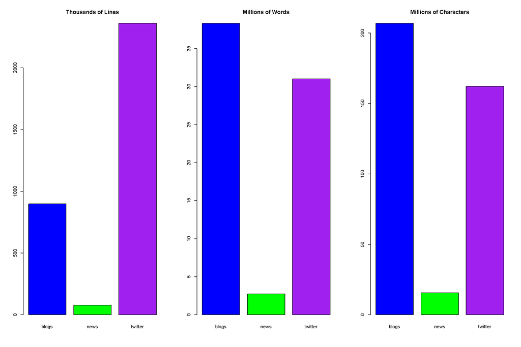

```r
par(mfrow = c(1, 3))
barplot(df_summary$Length/1000, names.arg = df_summary$Name, main = "Thousands of Lines",
    col = c("blue", "green", "purple"), beside = TRUE)
barplot(df_summary$Words/1e+06, names.arg = df_summary$Name, main = "Millions of Words",
    col = c("blue", "green", "purple"), beside = TRUE)
barplot(df_summary$Characters/1e+06, names.arg = df_summary$Name, main = "Millions of Characters",
    col = c("blue", "green", "purple"), beside = TRUE)
```

Look distribution of the length of lines.

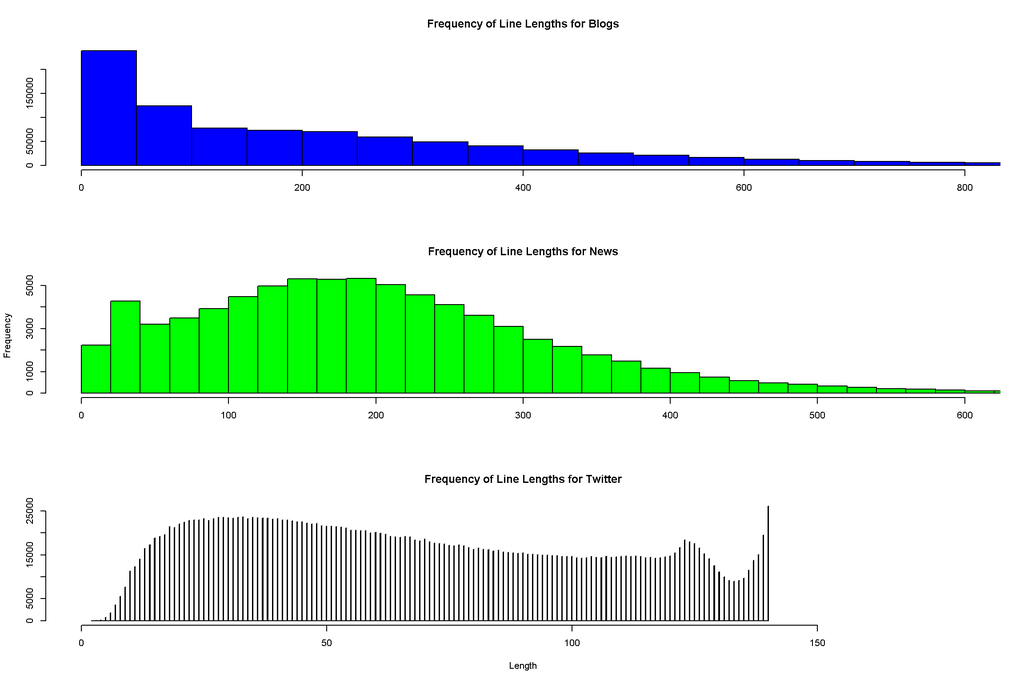

```r
load(file = "NCharacters.rda")

s <- sqrt(df_summary$Length)

par(mfrow = c(3, 1))
hist(NCharacters[[1]], main = "Frequency of Line Lengths for Blogs", xlim = c(0,
    800), xlab = "", ylab = "", col = "blue", breaks = s[1])
hist(NCharacters[[2]], main = "Frequency of Line Lengths for News", xlim = c(0, 600),
    xlab = "", ylab = "Frequency", col = "green", breaks = s[2])
hist(NCharacters[[3]], main = "Frequency of Line Lengths for Twitter", xlim = c(0,
    180), xlab = "Length", ylab = "", col = "purple", breaks = s[3])
```

```r
rm(NCharacters, s)
```

Look distribution of the number of words.

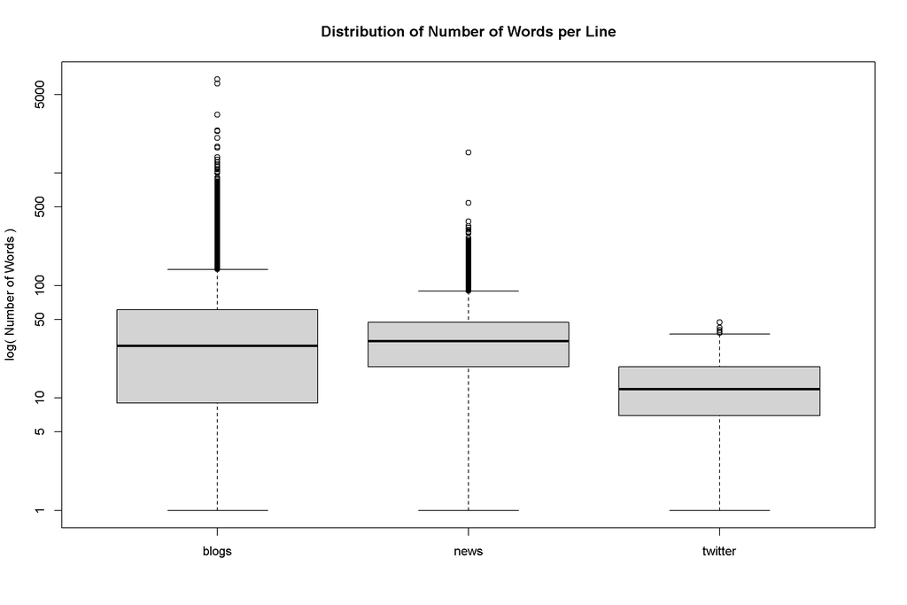

```r
load(file = "NWords.rda")

boxplot(NWords[[1]], NWords[[2]], NWords[[3]], log = "y", names = df_summary$Name,
    ylab = "log( Number of Words )", xlab = "", main = "Distribution of Number of Words per Line")
```

```r
rm(df_summary, NWords)
```

In view of the quantity of data and the distribution of line lengths, we decide to use only the twitter dataset as the other datasets do not seem suitable to answer the type of question we are considering. In particular, the news dataset is relatively small. The distribution of line lengths for the blogs dataset is too skewed towards short lines that we do not expect to build an **n-gram model** with good predictive power. Furthermore, it is not only intuitive but also supported by the literature that we can expect better results if we test using data from similar sources. So we reject mixing the datasets.

## Data cleaning

We assume independence so that each word depends only on the last n − 1 words in accordance with a Markov model (see references at end of this document). We do not expect to predict URLs, email addresses, words containing numbers or foreign characters, profanity, or stylistic punctuation.

Let’s clean the data to ignore content which is not useful or desired for prediction:

- remove words containing a digit
- remove words containing @ symbol such as email addresses
- remove tags in angled brackets <> such as HTML tags that may contain URLs
- remove URLs
- remove words containing such as folder names
- remove punctuation
- transform to lower case
- remove words containing letters other than a-z such as a foreign character
- remove extra white space
- remove profanity

Taking into account words have multiple meanings, we take a conservative view by considering a word as profane if

- it appears in what appears as a comprehensive list of such words, and
- is not in a dictionary for the language.

For example *breast* appears in the list we have chosen but that word is in Webster’s dictionary, and so we would not want to say it is a swear word. We use a couple lists in order to be more complete.

Also, we allow misspellings in our list of swear words for convenience as we do not intend to spell check. Remove words which should have been in dictionary, even though they may not be common or may be capitalized in usage.

First, we define **swear_words**.

```r
if (!file.exists("words")) {
    dir.create("words")
}
if (!file.exists("words/final")) {
    setwd("words")
    download.file("http://downloads.sourceforge.net/wordlist/scowl-2016.01.19.zip",
        destfile = "words.zip")
    if (file.exists("words.zip")) {
        unzip("words.zip")
        file.remove("words.zip")
    }
    setwd("../")
}

dict <- list.files(file.path("words", "final"), full.names = TRUE)
dict <- dict[as.numeric(tools::file_ext(dict)) <= 60 & grepl("english-", dict, fixed = TRUE)]

words <- unlist(sapply(dict, readLines, USE.NAMES = FALSE))
rm(dict)

require(stringi)
dfs <- read.csv(url("https://www.frontgatemedia.com/new/wp-content/uploads/2014/03/Terms-to-Block.csv"))
swear_words <- c()
v <- dfs[5:nrow(dfs), 2]
rm(dfs)

for (i in seq_along(v)) {
    v[i] <- stri_replace_all_fixed(v[i], ",", "")
}
v <- trimws(v)

v_ <- readLines("https://www.cs.cmu.edu/~biglou/resources/bad-words.txt", encoding = "UTF-8",
    skipNul = TRUE)
v_ <- trimws(v_[!v_ %in% v])


both <- intersect(v_, v)
v <- c(v, v_[!(v_ %in% both)])
v <- v[!(v %in% "")] %>% str_sort()

rm(both, v_)

for (i in seq_along(v)) {
    word <- v[i]
    if (!str_detect(word, "[-.0123456789 ]")) {
        if (!(word %in% words))
            swear_words <- c(swear_words, word)
    }
}

rm(v, words)
```

Next, we modify **swear_words** but omit the code.

Next, we clean the text and form a data frame to hold frequencies of words.

```r
cleanLine <- function(line) {
    line <- stri_replace_all_regex(str = line, pattern = "(<[^<>]*(<[^<>]*(<[^<>]*>[^<>]*)*>[^<>]*)*>)|(((https?|ftp)://[^\\s]*|((https?|ftp)://)?[\\w-]+(\\.[\\w-]+)+([\\w.,@?^=%&amp;:/~+#-]*[\\w@?^=%&amp;/~+#-])?))|([^[:ascii:]]*[rR][tT][^[:ascii:]]*)|([^\\s]*([0-9@\\\\])[^\\s]*)",
        replacement = "") %>%
    stri_replace_all_regex(pattern = "((^'+)|('+$)|(\\s'+)|('+\\s)|((?!')[[:punct:]])|[+^&*/|$<>=`~])|([^\\s]*[ñöüÄÅËÑÕÜäåëñöü][^\\s]*)",
        replacement = " ") %>% stri_replace_all_regex(pattern = "[^[:ascii:]]+",
        replacement = "") %>% tolower() %>% stri_replace_all_regex(pattern = "(?<=^| )[a-z']*([a-z])\\1{2,}[a-z']*(?=$| )",
        replacement = "") %>% stri_replace_all_regex(pattern = "(?<=^| )[a-z]?'[a-z](?=$| )",
        replacement = "") %>% stri_replace_all_regex(pattern = "(?<=^| )[^ai](?=$| )",
        replacement = "") %>% stri_replace_all_regex(pattern = "(?<=^| )([a][^adghimnrstwxy ]|[b][^aeioy ]|[c][a-z ]|[d][^ao ]|[e][^adefhmnrstwx ]|[f][^ae ]|[g][^io ]|[h][^aeimo ]|[i][^dfnost ]|[j][^ao ]|[k][^ai ]|[l][^aio ]|[m][^aeimouy ]|[n][^aeouy ]|[o][^bdefhimnoprsuwx ]|[p][^aeio ]|[q][^i ]|[r][^e ]|[s][^hio ]|[t][^abeio ]|[u][^ghmprst ]|[v][a-z ]|[w][^eo ]|[x][^iu ]|[y][^aeou ]|[z][^a ])(?=$| )",
        replacement = "")
    line <- unlist(strsplit(str_squish(line), " "))
    line <- line[!line %in% swear_words]
}

words <- as.vector(character(0))
freq <- as.vector(integer(0))
last <- 0L
c <- 0L
first <- 0L
low <- 0L
current <- 0L
high <- 0L
isshort <- TRUE
found <- FALSE
w <- character(0)
line <- as.vector(character(0))

for (i in seq_along(Text)) {
    line = cleanLine(Text[i])
    for (j in seq_along(line)) {
        w = line[j]

        found = FALSE

        if (isshort) {
            # linear search for w
            first = 0L  # INV: first is # of elements known to be smaller
            current = 1L  # INV: insertion index when finished
            if (current > last) {
                c = 1L
            } else {
                c <- stri_compare(words[current], w)
            }
            while (c < 0) {
                first = current
                current = current + 1L
                if (current > last) {
                  c = 1L
                } else {
                  c = stri_compare(words[current], w)
                }
            }
            found = (c == 0)
            isshort = (last < 9L)
        } else {
            low = 1L
            high = last

            c = stri_compare(words[low], w)
            if (c < 0) {
                is_to_right = TRUE

                c = stri_compare(w, words[high])
                if (c < 0) {
                  is_to_left = TRUE
                } else if (c == 0) {
                  current = high
                  found = TRUE
                  is_to_right = FALSE
                } else {
                  first = last
                  is_to_right = FALSE
                }

            } else {
                if (c == 0) {
                  current = low
                  found = TRUE
                  is_to_right = FALSE
                } else {
                  first = 0L
                  is_to_right = FALSE
                }
            }

            while (is_to_right && is_to_left) {

                current = (low + high)%/%2L
                if (current == low) {
                  first = low
                  current = high
                  break
                }

                c = stri_compare(words[current], w)

                if (c < 0) {
                  low = current
                } else if (c > 0) {
                  high = current
                } else {
                  found = TRUE
                  is_to_right = FALSE
                }
            }
        }

        if (found) {
            freq[current] = freq[current] + 1L
        } else {
            # add word with frequency
            if (first == 0) {
                words = c(c(w), words)
                freq = c(c(1), freq)
            } else if (first == last) {
                words = c(words, c(w))
                freq = c(freq, c(1))
            } else {
                words = c(words[1:first], c(w), words[current:last])
                freq = c(freq[1:first], c(1), freq[current:last])
            }
            last = last + 1L
        }
    }
    Text[i] <- paste(line, collapse = " ")
}

writeLines(Text, con = "Cleaned Text.txt")

df <- data.frame(word = words, freq = freq)
write.csv(df, "WordFreq.csv", row.names = FALSE)

varhandle::rm.all.but(keep = c("Text", "words", "freq"))
```

Let’s examine the frequencies of words.

```r
df <- read.csv(file = "WordFreq.csv")

require("Hmisc")
Hmisc::describe(df$freq)
```

```
## df$freq
##        n  missing distinct     Info     Mean      Gmd      .05      .10
##   297913        0     2864    0.827    96.29    187.8        1        1
##      .25      .50      .75      .90      .95
##        1        1        4       20       68
##
## lowest :      1      2      3      4      5, highest: 548259 617015 723572 788560 937242
```

```r
df <- df[order(df$freq, decreasing = TRUE), ]
print(df[1:20, ], row.names = FALSE)
```

```
##  word   freq
##   the 937242
##    to 788560
##     i 723572
##     a 617015
##   you 548259
##   and 438425
##   for 385197
##    in 380293
##    of 359571
##    is 358748
##    it 295902
##    my 291870
##    on 277952
##  that 234832
##    me 202236
##    be 187884
##    at 186706
##  with 173447
##  your 171207
##  have 168642
```

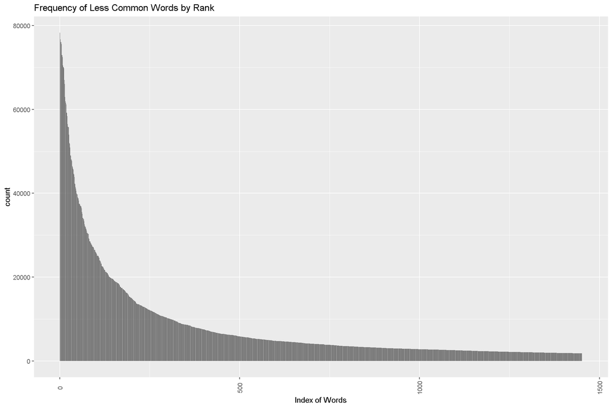

```r
f <- df[50:1500, ]

ggplot(f, aes(x = 1:nrow(f), y = freq)) + geom_bar(stat = "identity", width = 0.5) +
    theme(axis.text.x = element_text(angle = 90, vjust = 0.5)) + labs(title = "Frequency of Less Common Words by Rank",
    x = "Index of Words", y = "count")
```

```r
tail(f, 20)
```

[output not shown]

```r
rm(df, f)
```

## Partitioning the datasets

We partition our data into the usual sets for training, testing and validation.

```r
set.seed(10000169)

# Text <- readLines('Cleaned Text.txt')

Length = length(Text)

sizeTrain <- floor(Length * 0.6)
sizeTest <- floor((Length - sizeTrain)/2)
sizeValidate <- sizeTest

indicesTrain <- sort(sample(seq_len(Length), size = sizeTrain))
indicesTest <- setdiff(seq_len(Length), indicesTrain)
indicesValidate <- sort(sample(indicesTest, size = sizeValidate))
indicesTest <- setdiff(indicesTest, indicesValidate)

str(indicesTrain)
str(indicesTest)
str(indicesValidate)

# writeLines(Text[indicesTrain], con = 'Train.txt') writeLines(Text[indicesTest],
# con = 'Test.txt') writeLines(Text[indicesValidate], con = 'Validate.txt')

rm(indicesTrain, indicesTest, indicesValidate, Text)
```

[output not shown]

## Forming **n-grams**

We utilize the notion of a *corpus* for text mining in **R** and library *quanteda* to implement our algorithm (see Puschmann 2019)

```r
require("quanteda")

get_tokens <- function(filename) {
    tokens(x = corpus(readLines(paste0(filename, ".txt"))), what = "word", remove_punct = TRUE,
        remove_separators = TRUE, remove_symbols = TRUE)
}

ngram <- function(c, n) {
    d <- textstat_frequency(dfm(tokens_ngrams(c, n = n, concatenator = " "), tolower = FALSE))
    d <- data.frame(ngram = d$feature, count = d$frequency)
}

valid <- ngram(get_tokens("Validate"), 4L)
save(valid, file = "validate_4grams.rda")

test <- ngram(get_tokens("Test"), 4L)
save(test, file = "test_4grams.rda")

train_tokens <- get_tokens("Train")

train_2 <- ngram(train_tokens, 2L)
save(train_2, file = "train_2.rda")

train_3 <- ngram(train_tokens, 3L)
save(train_3, file = "train_3.rda")

train_4 <- ngram(train_tokens, 4L)
save(train_4, file = "train_4.rda")

rm(train_tokens)
```

## Implement algorithm

This is the original code without optimizations.

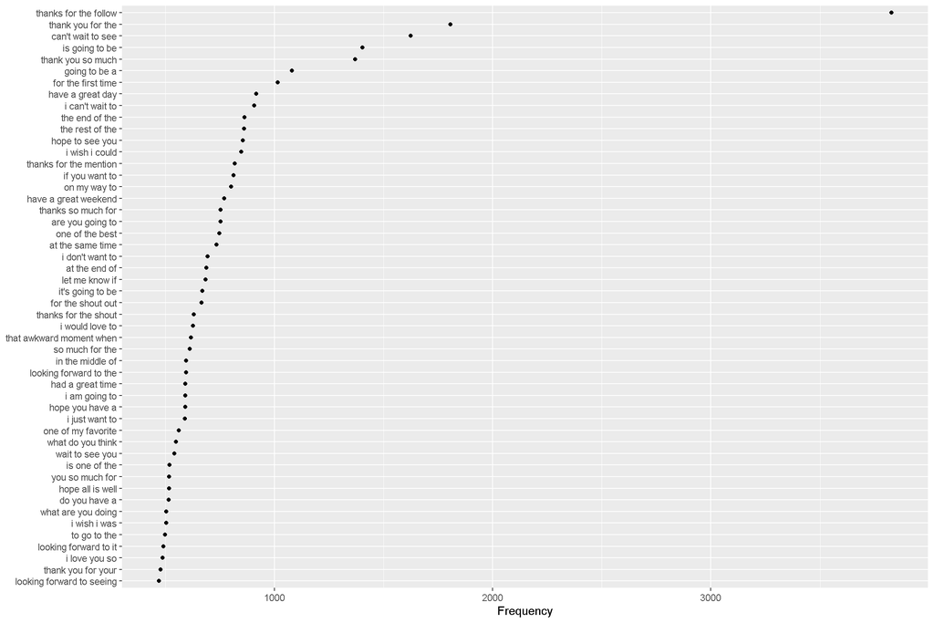

```r
load(file = "test_4grams.rda")
load(file = "train_2.rda")
load(file = "train_3.rda")
load(file = "train_4.rda")

require("ggplot2")
ggplot(train_4[1:50, ], aes(x = reorder(ngram, count), y = count)) + geom_point() +
    coord_flip() + labs(x = NULL, y = "Frequency")
```

```r
require("stringi")

predict <- function(p) {
    s <- unlist(strsplit(p, " "))
    t <- length(s)
    if (t >= 3) {
        if (t >= 4)
            s <- tail(s, 3)
        t <- train_4[str_starts(train_4$ngram, paste0(s[1], " ", s[2], " ", s[3])),
            ]
        if (nrow(t) == 0) {
            t <- train_3[str_starts(train_3$ngram, paste0(s[2], " ", s[3])), ]
            if (nrow(t) == 0) {
                t <- train_2[str_starts(train_2$ngram, s[3]), ]
                if (nrow(t) == 0) {
                  t <- train_3[str_starts(train_3$ngram, paste0(s[1], " ", s[2])),
                    ]
                  if (nrow(t) == 0) {
                    t <- NA
                  } else {
                    t <- unlist(strsplit(t[1, 1], " "))[3]
                  }
                  if (is.na(t) || (stri_cmp_eq(t, s[3]))) {
                    t <- train_2[str_starts(train_2$ngram, s[2]), ]
                    if (nrow(t) == 0) {
                      t <- NA
                    } else {
                      t <- unlist(strsplit(t[1, 1], " "))[2]
                    }
                    if (is.na(t) || (stri_cmp_eq(t, s[3]))) {
                      t <- train_2[str_starts(train_2$ngram, s[1]), ]
                      if (nrow(t) == 0) {
                        t <- NA
                      } else {
                        t <- unlist(strsplit(t[1, 1], " "))[2]
                      }
                      if (is.na(t) || (stri_cmp_eq(t, s[3]))) {
                        t <- NA
                      }
                    }
                  }
                } else {
                  t <- unlist(strsplit(t[1, 1], " "))[2]
                }
            } else {
                t <- unlist(strsplit(t[1, 1], " "))[3]
            }
        } else {
            t <- unlist(strsplit(t[1, 1], " "))[4]
        }
    } else if (t == 2) {
        t <- train_3[str_starts(train_3$ngram, p), ]
        if (nrow(t) == 0) {
            t <- train_2[str_starts(train_2$ngram, s[2]), ]
            if (nrow(t) == 0) {
                t <- train_2[str_starts(train_2$ngram, s[1]), ]
                if (nrow(t) == 0) {
                  t <- NA
                } else {
                  t <- unlist(strsplit(t[1, 1], " "))[2]
                  if (stri_cmp_eq(t, s[2])) {
                    t <- NA
                  }
                }
            } else {
                t <- unlist(strsplit(t[1, 1], " "))[2]
            }
        } else {
            t <- unlist(strsplit(t[1, 1], " "))[3]
        }
    } else if (t == 1) {
        t <- train_2[str_starts(train_2$ngram, p), ]
        if (nrow(t) == 0) {
            t <- NA
        } else {
            t <- unlist(strsplit(t[1, 1], " "))[2]
        }
    } else {
        t = NA
    }
    t
}

s <- "thank you so much"
p <- unlist(strsplit(s, " "))
zc <- p[4]
p <- paste0(p[1], " ", p[2], " ", p[3])
z <- predict(p)
print(paste0("Using string '", p, "', our algorithm ", if (stri_cmp_eq(z, zc)) {
    ""
} else {
    "in"
}, "correctly predicts ", if (is.na(z)) {
    "NA"
} else {
    z
}))
```

```
## [1] "Using string 'thank you so', our algorithm correctly predicts much"
```

```r
s <- "how are you"
p <- unlist(strsplit(s, " "))
zc <- p[3]
p <- paste0(p[1], " ", p[2])
z <- predict(p)
print(paste0("Using string '", p, "', our algorithm ", if (stri_cmp_eq(z, zc)) {
    ""
} else {
    "in"
}, "correctly predicts ", if (is.na(z)) {
    "NA"
} else {
    z
}))
```

```
## [1] "Using string 'how are', our algorithm correctly predicts you"
```

## References

Brants, Thorsten, Ashok C. Popat, Peng Xu, Franz J. Och, and Jeffrey Dean. 2007. “Large Language Models in Machine Translation.” In *Proceedings of the 2007 Joint Conference on Empirical Methods in Natural Language Processing and ComputationalNatural Language Learning*, 858–67. Association for Computational Linguistics. https://www.aclweb.org/anthology/D07-1090.pdf.

Gale, William A., and Geoffrey Sampson. 1995. “Good–Turing Frequency Estimation Without Tears.” *Journal of Quantitative Linguistics* 2 (3): 217–37. https://doi.org/10.1080/09296179508590051.

Jurafsky, Daniel, and James H. Martin. 2020. “N-Gram Language Models.” *Speech and Language Processing*. https://web.stanford.edu/~jurafsky/slp3/3.pdf.

Puschmann, Cornelius. 2019. “Advancing Text Mining with R and Quanteda.” Methods Bites. October 2019. https://www.mzes.uni-mannheim.de/socialsciencedatalab/article/advancing-text-mining/.

Sampson, Geoffrey. 2017. “Good–Turing Frequency Estimation.” November 2017. https://www.grsampson.net/RGoodTur.html.

Wikipedia contributors. 2021a. “Katz’s Back-Off Model.” Wikipedia, The Free Encyclopedia. January 2021. https://en.wikipedia.org/w/index.php?title=Katz%27s_back-off_model&oldid=991317475.

———. 2021b. “N-Gram.” Wikipedia, The Free Encyclopedia. January 2021. https://en.wikipedia.org/w/index.php?title=N-gram&oldid=998158976.